# Exploring Distributions

In exploring statistical distributions, we focus on the following:

- what influences the shape of a distribution
- calculate probability from a given quantile
- calculate quantiles out of given probability

To explore the above 3 concepts, we have defined functions for the following distributions:

- Normal
- Binomial
- Chi Square
- F
- t

## Normal Distribution

### Distribution Shape

Visualize how changes in mean and standard deviation affect the shape of the normal distribution.

##### Input

- mean: mean of the normal distribution
- sd: standard deviation of the normal distribution

##### Output

- Normal distribution plot

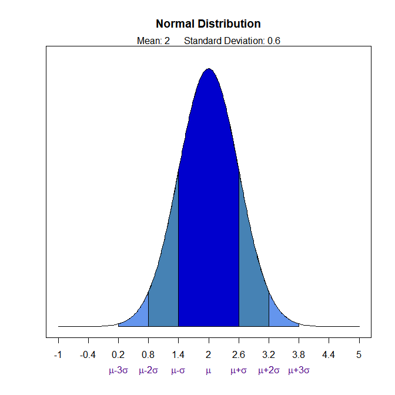

```r
dist_norm_plot(mean = 2, sd = 0.6)
```

### Percentiles

#### Calculate and visualize quantiles out of given probability.

##### Input

- probs: a probability value
- mean: mean of the normal distribution
- sd: standard deviation of the normal distribution
- type: lower/upper tail

Suppose X, the grade on a exam, is normally distributed with mean 60 and standard deviation 3. The teacher wants to give 10% of the class an A. What should be the cutoff to determine who gets an A?

```r
dist_norm_perc(0.10, 60, 3, 'upper')
```

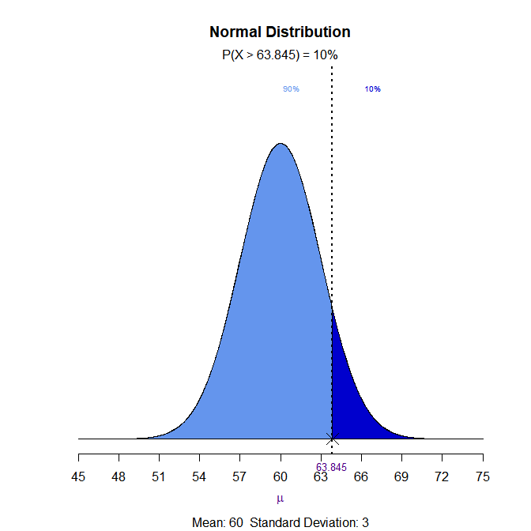

```r
dist_norm_perc(0.85, 60, 3, 'lower')
```

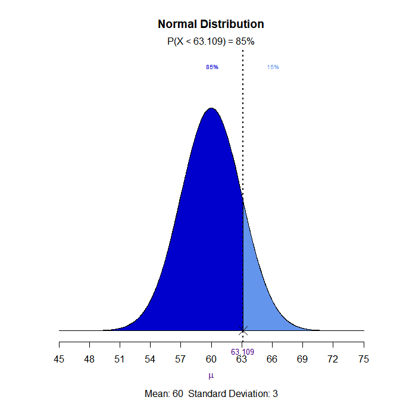

The teacher wants to give middle 50% of the class a B. What cutoff should the teacher use to determine who gets an B?

```r
dist_norm_perc(0.5, 60, 3, 'both')
```

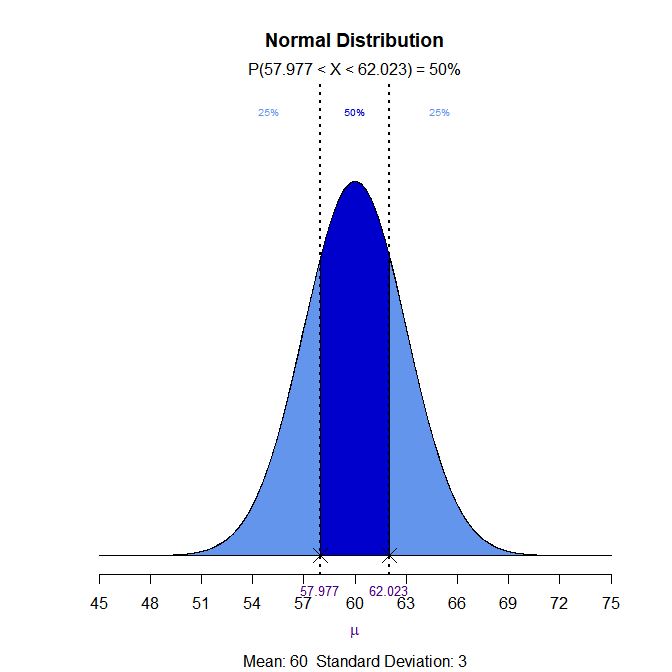

### Probabilities

#### Calculate and visualize probability from a given quantile

##### Input

- perc: a quantile value
- mean: mean of the normal distribution
- sd: standard deviation of the normal distribution
- type: lower/upper/both tail

Let X be the IQ of a randomly selected student of a school. Assume X ~ N(90, 4). What is the probability that a randomly selected student has an IQ below 80?

```r
dist_norm_prob(80, mean = 90, sd = 4)
```

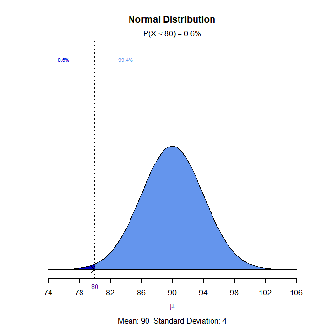

What is the probability that a randomly selected student has an IQ above 100?

```r
dist_norm_prob(100, mean = 90, sd = 4, type = 'upper')
```

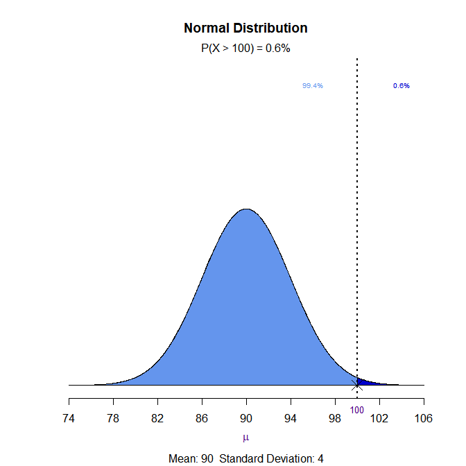

What is the probability that a randomly selected student has an IQ between 85 and 100?

```r
dist_norm_prob(c(85, 100), mean = 90, sd = 4, type = 'both')
```

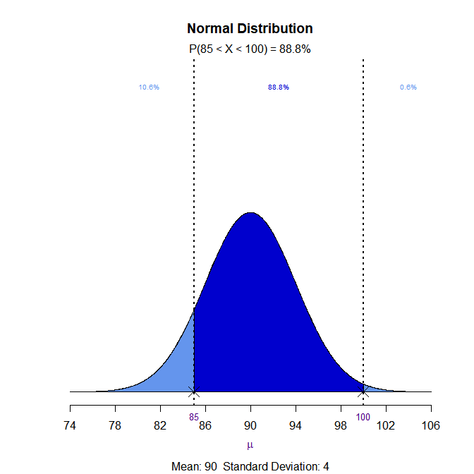

## Binomial Distribution

### Distribution Shape

Visualize how changes in number of trials and the probability of success affect the shape of the binomial distribution.

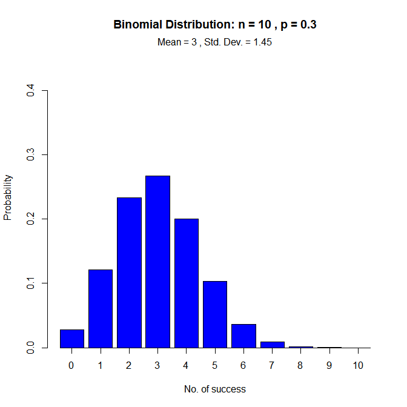

```r
dist_binom_plot(10, 0.3)
```

### Percentiles

#### Calculate and visualize quantiles out of given probability

##### Input

- p: a single aggregated probability of multiple trials
- n: the number of trials
- tp: the probability of success in a trial
- type: lower/upper tail

```r
dist_binom_perc(10, 0.5, 0.05)
```

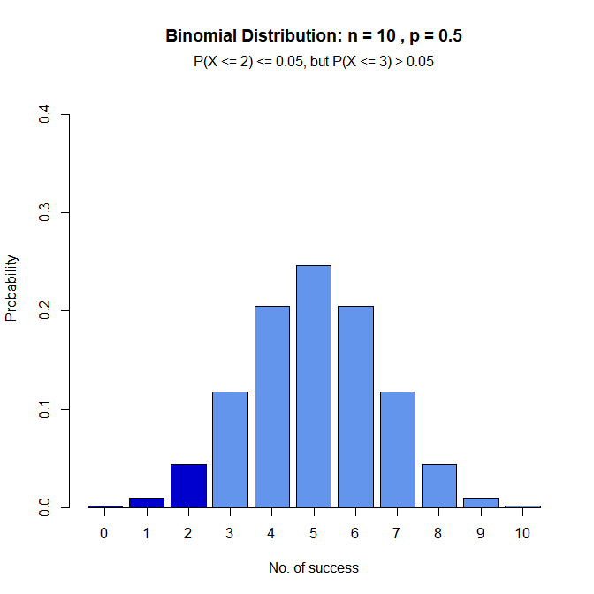

```r
dist_binom_perc(10, 0.5, 0.05, 'upper')
```

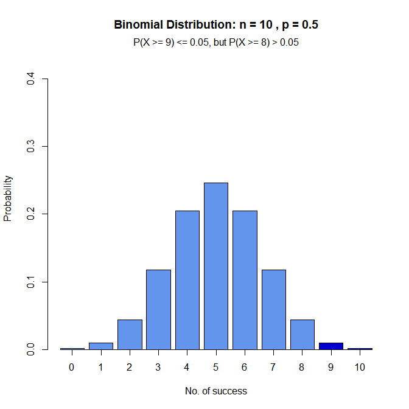

### Probabilities

#### Calculate and visualize probability from a given quantile

##### Input

- p: probability of success
- n: the number of trials
- s: number of success in a trial
- type: lower/upper/interval/exact tail

```r
dist_binom_prob(12, 0.2, 4, type = 'exact')
```

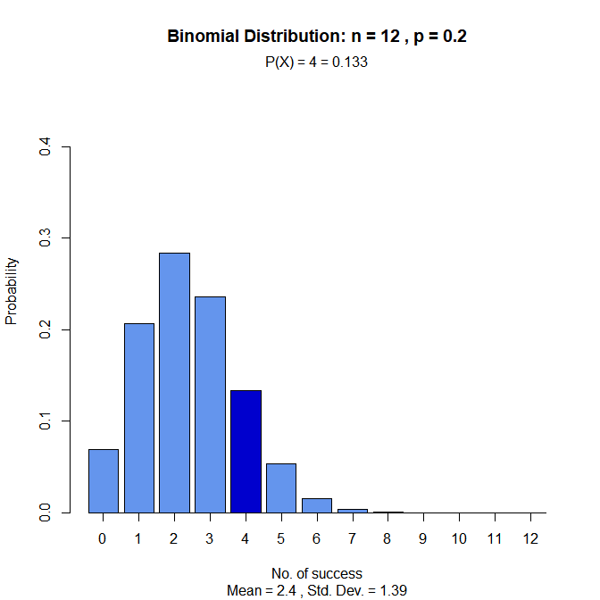

```r
dist_binom_prob(12, 0.2, 1, 'lower')
```

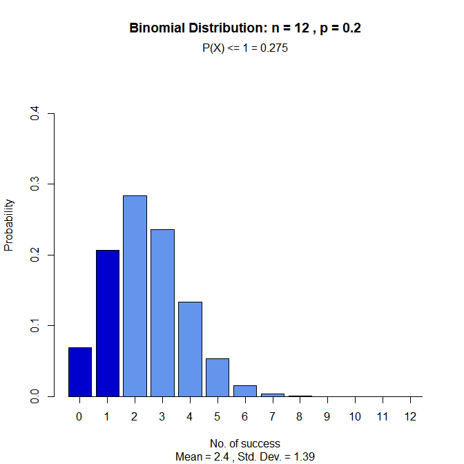

What is the probability that more than seven have no health insurance?

```r
dist_binom_prob(12, 0.2, 8, 'upper')
```

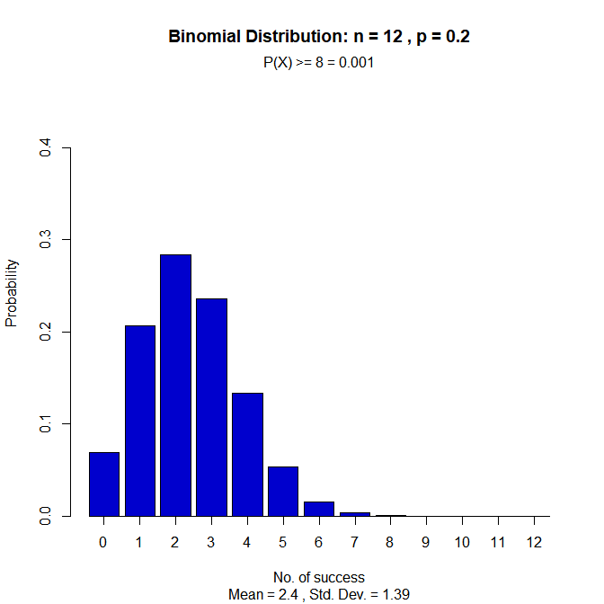

What is the probability that fewer than 5 have no health insurance?

```r
dist_binom_prob(12, 0.2, c(0, 4), 'interval')
```

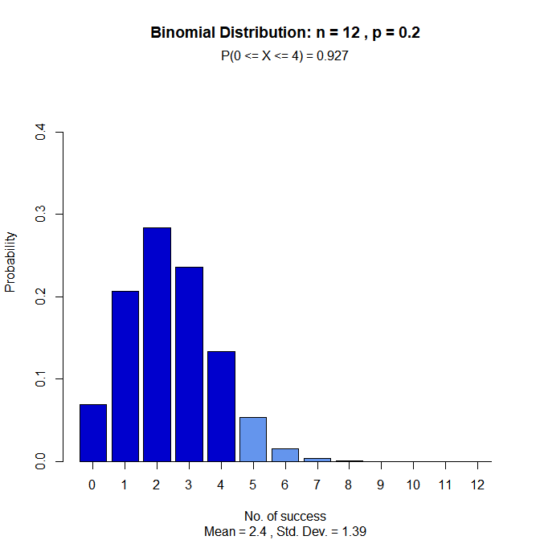

## Chi Square Distribution

### Distribution Shape

Visualize how changes in degrees of freedom affect the shape of the chi square distribution.

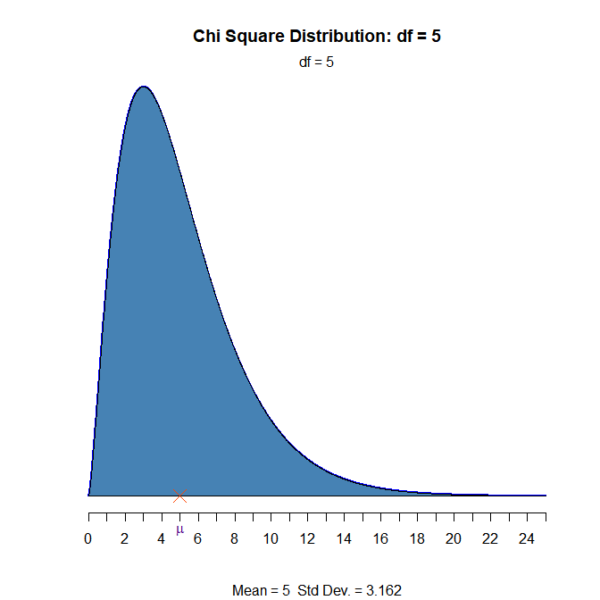

```r
dist_chi_plot(df = 5)
```

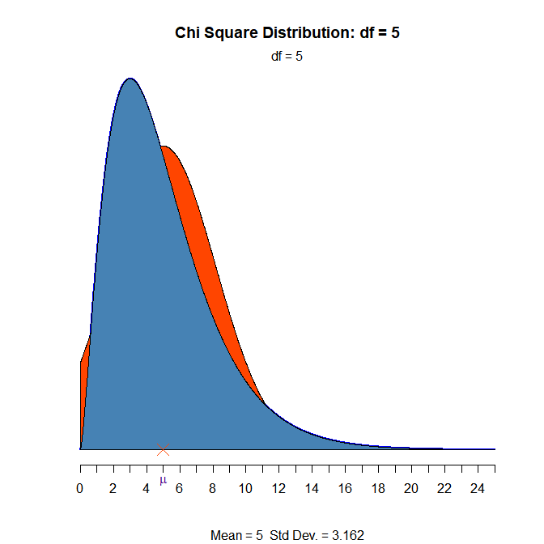

```r
dist_chi_plot(df = 5, normal = TRUE)
```

### Percentiles

#### Calculate quantiles out of given probability

##### Input

- probs: a probability value
- df: degrees of freedom
- type: lower/upper tail

Let X be a chi-square random variable with 8 degrees of freedom. What is the upper fifth percentile?

```r
dist_chi_perc(0.05, 8, 'upper')
```

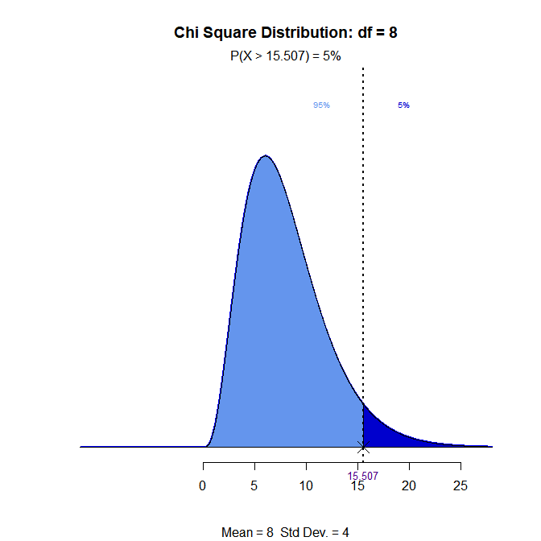

What is the tenth percentile?

```r
dist_chi_perc(0.10, 8, 'lower')
```

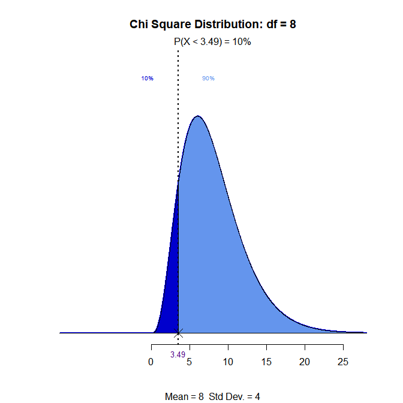

### Probability

#### Calculate probability from a given quantile.

##### Input

- perc: a quantile value
- df: degrees of freedom
- type: lower/upper tail

What is the probability that a chi-square random variable with 12 degrees of freedom is greater than 8.79?

```r
dist_chi_prob(8.79, 12, 'upper')
```

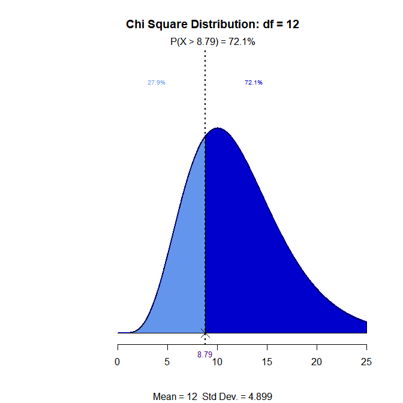

```r
dist_chi_prob(8.62, 12, 'lower')
```

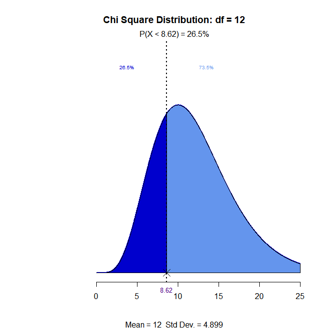

## F Distribution

### Distribution Shape

Visualize how changes in degrees of freedom affect the shape of the F distribution.

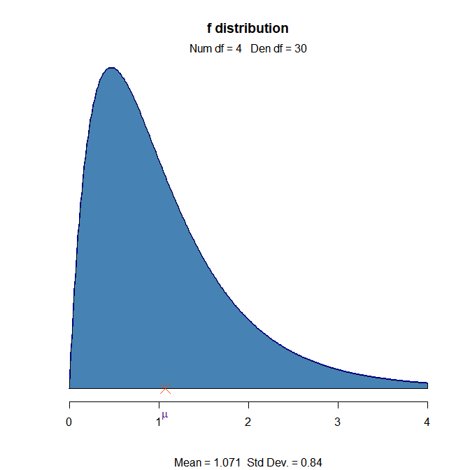

```r
dist_f_plot()
```

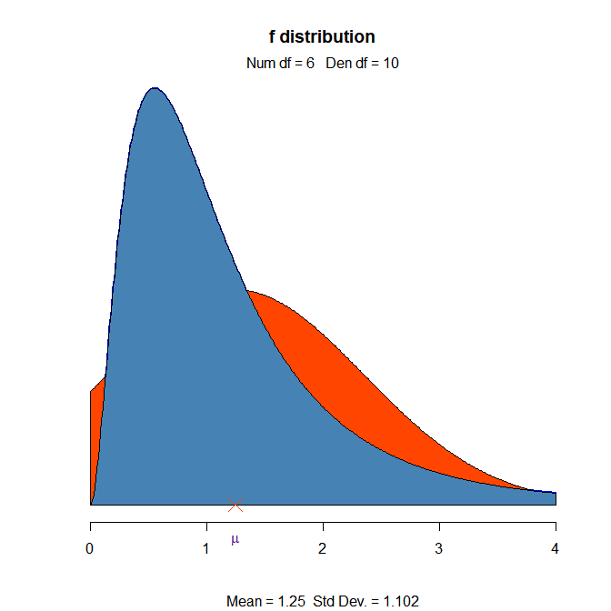

```r
dist_f_plot(6, 10, normal = TRUE)
```

### Percentiles

#### Calculate quantiles out of given probability

##### Input

- probs: a probability value
- num_df: nmerator degrees of freedom
- den_df: denominator degrees of freedom
- type: lower/upper tail

Let X be an F random variable with 4 numerator degrees of freedom and 5 denominator degrees of freedom. What is the upper twenth percentile?

```r
dist_f_perc(0.20, 4, 5, 'upper')
```

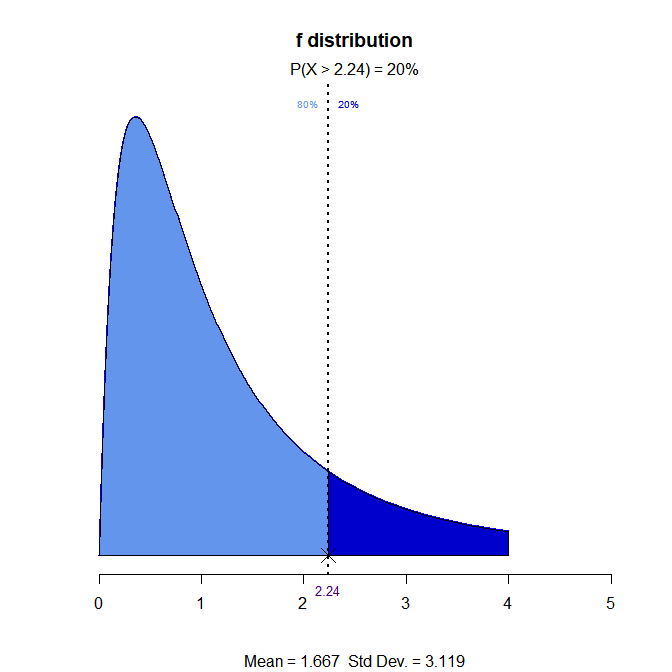

What is the 35th percentile?

```r
dist_f_perc(0.35, 4, 5, 'lower')
```

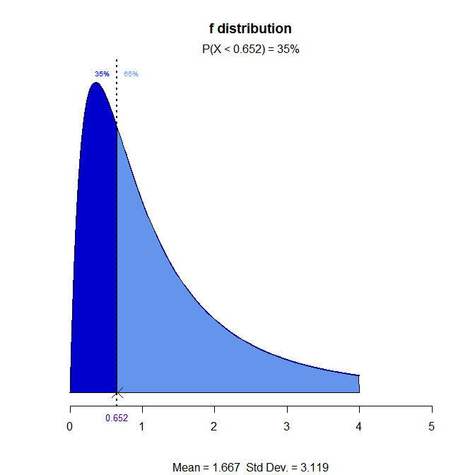

### Probabilities

#### Calculate probability from a given quantile.

##### Input

- perc: a quantile value
- num_df: nmerator degrees of freedom
- den_df: denominator degrees of freedom
- type: lower/upper tail

What is the probability that an F random variable with 4 numerator degrees of freedom and 5 denominator degrees of freedom is greater than 3.89?

```r
dist_f_prob(3.89, 4, 5, 'upper')
```

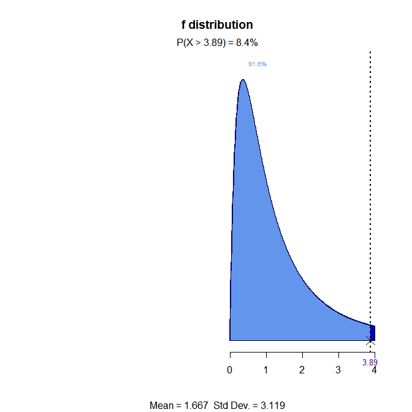

What is the probability that an F random variable with 4 numerator degrees of freedom and 5 denominator degrees of freedom is less than 2.63?

```r
dist_f_prob(2.63, 4, 5, 'lower')
```

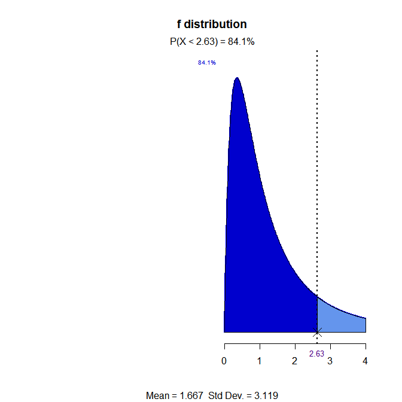

## t Distribution

### Distribution Shape

Visualize how degrees of freedom affect the shape of t distribution.

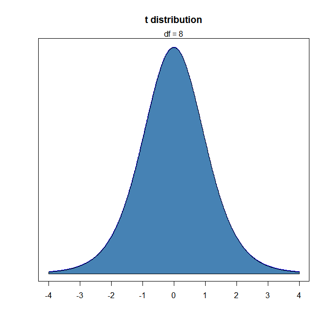

```r
dist_t_plot(df = 8)
```

### Percentiles

#### Calculate quantiles out of given probability

##### Input

- probs: a probability value
- df: degrees of freedom
- type: lower/upper/both tail

What is the upper fifteenth percentile?

```r
dist_t_perc(0.15, 8, 'upper')
```

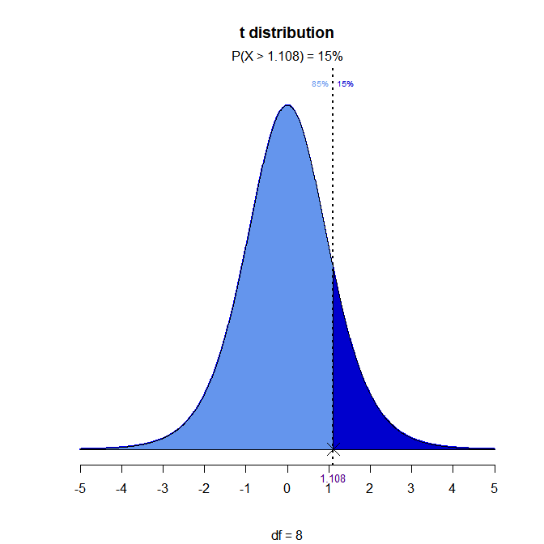

What is the eleventh percentile?

```r
dist_t_perc(0.11, 8, 'lower')
```

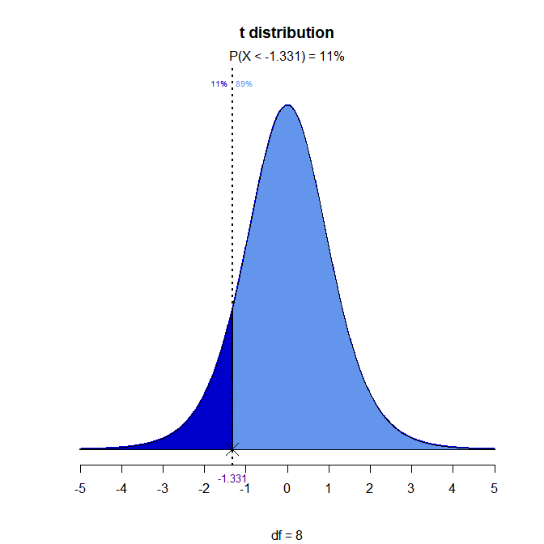

```r
dist_t_perc(0.8, 8, 'both')
```

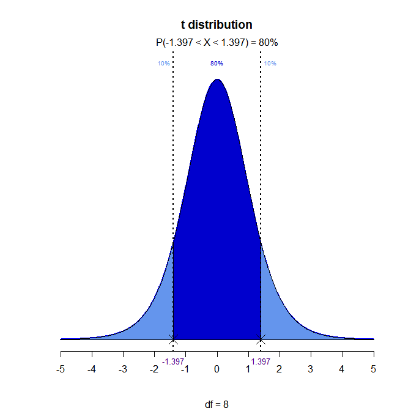

### Probabilities

#### Calculate probability from a given quantile.

##### Input

- perc: a quantile value
- df: degrees of freedom
- type: lower/upper/interval/both tail

Let T follow a t-distribution with r = 6 df.

What is the probability that the value of T is less than 2?

```r
dist_t_prob(2, 6, 'lower')
```

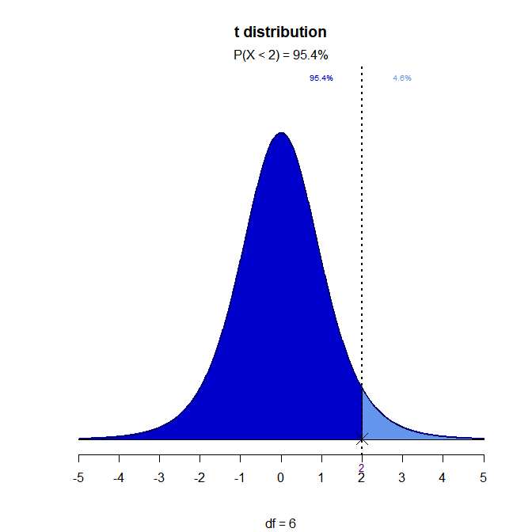

What is the probability that the value of T is greater than 2?

```r
dist_t_prob(2, 6, 'upper')
```

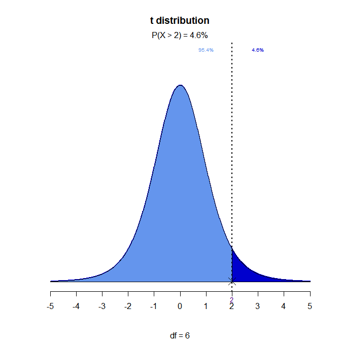

```r
dist_t_prob(2, 6, 'both')
```

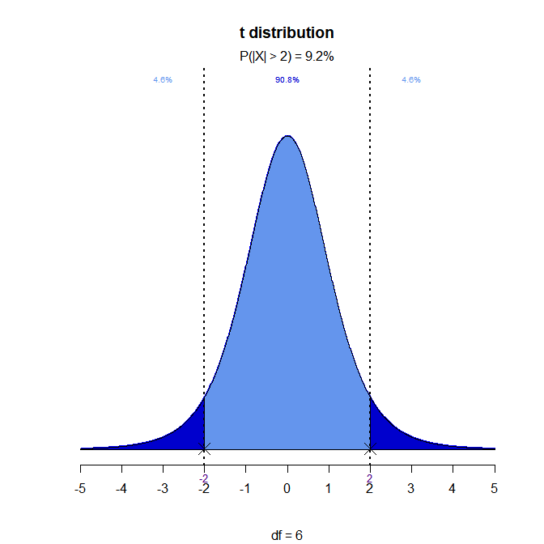

```r
dist_t_prob(2, 6, 'interval')
```

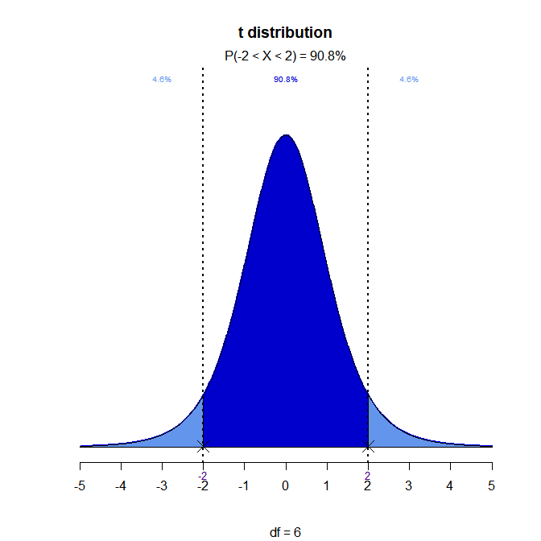